# Pandas (Panel Data Analysis)

```python
from IPython.display import Image, HTML
```

```python
%load_ext load_style
%load_style talk.css
```

```python
import numpy as np
import matplotlib.pyplot as plt
```

```python
%matplotlib inline
```

```python
HTML('<iframe src=http://pandas.pydata.org/index.html width=900 height=350></iframe>')
```

[interactive chart not shown]

```python
import pandas as pd
```

```python
pd.set_option("line_width", 80)
# toggle the line below that if one doesnt want DataFrames displayed as HTML tables
#pd.set_option("notebook_repr_html", False)
pd.set_option("notebook_repr_html", True)
```

**pandas** is a Python package providing fast, flexible, and expressive data structures designed to work with *relational* or *labeled* data. It is a fundamental high-level building block for doing practical, real world data analysis in Python.

pandas is well suited for:

- Tabular data with heterogeneously-typed columns, as in an SQL table or Excel spreadsheet
- Ordered and unordered (not necessarily fixed-frequency) time series data.
- Arbitrary matrix data (homogeneously typed or heterogeneous) with row and column labels
- Any other form of observational / statistical data sets. The data actually need not be labeled at all to be placed into a pandas data structure

Key features:

- Easy handling of **missing data**
- **Size mutability**: columns can be inserted and deleted from DataFrame and higher dimensional objects
- Automatic and explicit **data alignment**: objects can be explicitly aligned to a set of labels, or the data can be aligned automatically
- Powerful, flexible **group by functionality** to perform split-apply-combine operations on data sets
- Intelligent label-based **slicing, fancy indexing, and subsetting** of large data sets
- Intuitive **merging and joining** data sets
- Flexible **reshaping and pivoting** of data sets
- **Hierarchical labeling** of axes
- Robust **IO tools** for loading data from flat files, Excel files, databases, and HDF5
- **Time series functionality**: date range generation and frequency conversion, moving window statistics, moving window linear regressions, date shifting and lagging, etc.

Pandas's data structures and functionalities will be familiar to R users, there's a section on Pandas's website where Wes McKinney gives some translation of common idioms / operations between R and Pandas

```python
HTML('<iframe src=http://pandas.pydata.org/pandas-docs/stable/comparison_with_r.html#compare-with-r width=900 height=350></iframe>')
```

[interactive chart not shown]

## 1. Pandas data structures

### 1.1. Series

A **Series** is a single vector of data values (think a NumPy array with shape N or (N,1)) with an **index** that labels each element in the vector.

```python
a = pd.Series(np.random.normal(0,1,(10,)))
```

```python
a
```

```
0    0.515109
1   -0.481021
2   -0.859469
3   -0.818741
4    0.163780
5   -0.639470
6    0.762767
7    2.322911
8    1.129654
9   -1.012590
dtype: float64
```

```python
b = a
```

```python
b = b.mean()
```

```python
b
```

```
0.10829310928343608
```

```python
a
```

```
0    0.515109
1   -0.481021
2   -0.859469
3   -0.818741
4    0.163780
5   -0.639470
6    0.762767
7    2.322911
8    1.129654
9   -1.012590
dtype: float64
```

```python
a.index
```

```
Int64Index([0, 1, 2, 3, 4, 5, 6, 7, 8, 9], dtype='int64')
```

```python
a.values
```

```
array([ 0.51510939, -0.48102095, -0.85946922, -0.81874054,  0.16377954,
       -0.63946957,  0.76276735,  2.32291094,  1.12965396, -1.01258981])
```

#### You can define your own **index**

```python
a = pd.Series(np.random.normal(0,1,(10,)), index=np.arange(1,11))
```

```python
a.index
```

```
Int64Index([1, 2, 3, 4, 5, 6, 7, 8, 9, 10], dtype='int64')
```

```python
a = pd.Series(np.random.normal(0,1,5), index=['a','b','c','d','e'], name='my series')
```

```python
a
```

```
a    0.489256
b   -1.675855
c    1.156451
d    1.851782
e    0.864339
Name: my series, dtype: float64
```

Pandas objects expose some powerful, high level plotting functions (built on top of Matplotlib)

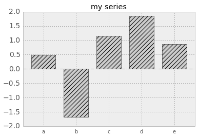

```python
plot = a.plot(kind='bar', rot=0, color='.8', title=a.name, hatch='///', edgecolor='k')
```

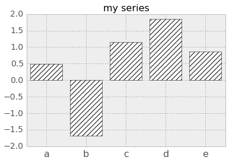

```python
f, ax = plt.subplots()
bars = ax.bar(np.arange(len(a)), a.values, color='w', edgecolor='k', align='center', hatch='///')
ax.set_xticks(np.arange(len(a)))
ax.set_xlim(-0.5, len(a)-0.5)
ax.set_xticklabels(a.index, fontsize=16)
ax.set_title(a.name, fontsize=16)
```

Selecting from a Series is easy, using the corresponding index key (like a dict)

```python
a['c']
```

```
1.1564513737482971
```

slices are permitted

```python
a['a':'c'] ### Note the difference with standard Python / Numpy positional, integer indexing
```

```
a    0.489256
b   -1.675855
c    1.156451
Name: my series, dtype: float64
```

```python
a['c':]
```

```
c    1.156451
d    1.851782
e    0.864339
Name: my series, dtype: float64
```

deleting an element

```python
a.drop('d')
```

```
a    0.489256
b   -1.675855
c    1.156451
e    0.864339
Name: my series, dtype: float64
```

Adding an element is (to my knowledge) not straightforward

```python
a.append(pd.Series({'f':5}))
```

```
a    0.489256
b   -1.675855
c    1.156451
d    1.851782
e    0.864339
f    5.000000
dtype: float64
```

Mathematical operations involving two series will perform operations by *aligning indices*.

1. The union of all indices is created
2. The mathematical operation is performed on matching indices.

Indices that do not match are given the value NaN (not a number), and values are computed for all unique pairs of repeated indices.

```python
s1 = pd.Series(np.arange(1.0,4.0),index=['a','b','c'])
s2 = pd.Series(np.arange(1.0,4.0),index=['b','c','d'])
```

```python
s3 = s1 + s2
```

```python
s3
```

```
a   NaN
b     3
c     5
d   NaN
dtype: float64
```

NaNs are ignored in all operations

```python
s3.mean()
```

```
4.0
```

You can drop them from the Series

```python
s4 = s3.dropna()
```

```python
s4
```

```
b    3
c    5
dtype: float64
```

Or use the `fillna` method to replace them by a value

```python
s3.fillna(-999)
```

```
a   -999
b      3
c      5
d   -999
dtype: float64
```

```python
s3.fillna(s3.mean())
```

```
a    4
b    3
c    5
d    4
dtype: float64
```

Series can have indexes representing dates / times

```python
a
```

```
a    0.489256
b   -1.675855
c    1.156451
d    1.851782
e    0.864339
Name: my series, dtype: float64
```

```python
a.index = pd.date_range(start='2014-1-1', periods=len(a)) # default 'period' is daily
```

```python
a.head()
```

```
2014-01-01    0.489256
2014-01-02   -1.675855
2014-01-03    1.156451
2014-01-04    1.851782
2014-01-05    0.864339
Freq: D, Name: my series, dtype: float64
```

```python
a.index
```

```
<class 'pandas.tseries.index.DatetimeIndex'>
[2014-01-01, ..., 2014-01-05]
Length: 5, Freq: D, Timezone: None
```

```python
### a datetime index in Pandas has its own type
a.index
```

```
<class 'pandas.tseries.index.DatetimeIndex'>
[2014-01-01, ..., 2014-01-05]
Length: 5, Freq: D, Timezone: None
```

```python
### but you can convert it to an numpy array of python datetime objects if you want
py_datetimes = a.index.to_pydatetime()
```

```python
py_datetimes
```

```
array([datetime.datetime(2014, 1, 1, 0, 0),
       datetime.datetime(2014, 1, 2, 0, 0),
       datetime.datetime(2014, 1, 3, 0, 0),
       datetime.datetime(2014, 1, 4, 0, 0),
       datetime.datetime(2014, 1, 5, 0, 0)], dtype=object)
```

And a number of useful methods for manipulation of time series is exposed

```python
### resample daily time-series to 5 minutes 'period', using forward filling method
a.resample('5min',fill_method='ffill')
```

```
2014-01-01 00:00:00    0.489256
2014-01-01 00:05:00    0.489256
2014-01-01 00:10:00    0.489256
2014-01-01 00:15:00    0.489256
2014-01-01 00:20:00    0.489256
2014-01-01 00:25:00    0.489256
2014-01-01 00:30:00    0.489256
2014-01-01 00:35:00    0.489256
2014-01-01 00:40:00    0.489256
2014-01-01 00:45:00    0.489256
2014-01-01 00:50:00    0.489256
2014-01-01 00:55:00    0.489256
2014-01-01 01:00:00    0.489256
2014-01-01 01:05:00    0.489256
2014-01-01 01:10:00    0.489256
...
2014-01-04 22:50:00    1.851782
2014-01-04 22:55:00    1.851782
2014-01-04 23:00:00    1.851782
2014-01-04 23:05:00    1.851782
2014-01-04 23:10:00    1.851782
2014-01-04 23:15:00    1.851782
2014-01-04 23:20:00    1.851782
2014-01-04 23:25:00    1.851782
2014-01-04 23:30:00    1.851782
2014-01-04 23:35:00    1.851782
2014-01-04 23:40:00    1.851782
2014-01-04 23:45:00    1.851782
2014-01-04 23:50:00    1.851782
2014-01-04 23:55:00    1.851782
2014-01-05 00:00:00    0.864339
Freq: 5T, Name: my series, Length: 1153
```

```python
a
```

```
2014-01-01    0.489256
2014-01-02   -1.675855
2014-01-03    1.156451
2014-01-04    1.851782
2014-01-05    0.864339
Freq: D, Name: my series, dtype: float64
```

````python
### the ```shift``` method makes it easy e.g. to compare series with lead / lags
a.shift(periods=-1)
````

```
2014-01-01   -1.675855
2014-01-02    1.156451
2014-01-03    1.851782
2014-01-04    0.864339
2014-01-05         NaN
Freq: D, Name: my series, dtype: float64
```

````python
### and the ```truncate`` method allows easy selection of time-slices
a.truncate(after='2014-1-2')
````

```
2014-01-01    0.489256
2014-01-02   -1.675855
Freq: D, Name: my series, dtype: float64
```

### 1.2. DataFrames

DataFrames are IMHO one of the most powerful data structures in the Python / data analysis world.

They can be viewed as a *collection* of Series. They feature two indexes, respectively for the rows and the columns, and can contain heteregoneous data types (although it must be consistent *within* each column).

Note that a DataFrame index, either along the rows or the columns (or both !) can contain more than one level, they are called **hierarchical indexes** and allows the representation of complex data organisation.

If the index along the rows of a DataFrame is of **datetime** type, all the methods exposed for the Series (re-sampling, shifting, truncating, etc) are available for the DataFrame.

```python
import string # part of the standard library
idx = list(string.lowercase[:10])
print(idx)
```

```
['a', 'b', 'c', 'd', 'e', 'f', 'g', 'h', 'i', 'j']
```

```python
df = pd.DataFrame(np.arange(100).reshape(10,10),columns=idx,index=np.arange(1,11))
```

```python
df
```

|  | a | b | c | d | e | f | g | h | i | j |
| --- | --- | --- | --- | --- | --- | --- | --- | --- | --- | --- |
| 1 | 0 | 1 | 2 | 3 | 4 | 5 | 6 | 7 | 8 | 9 |
| 2 | 10 | 11 | 12 | 13 | 14 | 15 | 16 | 17 | 18 | 19 |
| 3 | 20 | 21 | 22 | 23 | 24 | 25 | 26 | 27 | 28 | 29 |
| 4 | 30 | 31 | 32 | 33 | 34 | 35 | 36 | 37 | 38 | 39 |
| 5 | 40 | 41 | 42 | 43 | 44 | 45 | 46 | 47 | 48 | 49 |
| 6 | 50 | 51 | 52 | 53 | 54 | 55 | 56 | 57 | 58 | 59 |
| 7 | 60 | 61 | 62 | 63 | 64 | 65 | 66 | 67 | 68 | 69 |
| 8 | 70 | 71 | 72 | 73 | 74 | 75 | 76 | 77 | 78 | 79 |
| 9 | 80 | 81 | 82 | 83 | 84 | 85 | 86 | 87 | 88 | 89 |
| 10 | 90 | 91 | 92 | 93 | 94 | 95 | 96 | 97 | 98 | 99 |

10 rows × 10 columns

```python
### here I am creating a DataFrame from a dictionnary

df = pd.DataFrame({'A' : np.random.random(5), 'B' : np.random.random(5), 'C': np.random.random(5)})
print df
```

```
          A         B         C
0  0.576212  0.497153  0.155229
1  0.338768  0.019293  0.991341
2  0.277941  0.445321  0.593195
3  0.178222  0.786506  0.855407
4  0.695456  0.457891  0.296605

[5 rows x 3 columns]
```

```python
df
```

|  | A | B | C |
| --- | --- | --- | --- |
| 0 | 0.576212 | 0.497153 | 0.155229 |
| 1 | 0.338768 | 0.019293 | 0.991341 |
| 2 | 0.277941 | 0.445321 | 0.593195 |
| 3 | 0.178222 | 0.786506 | 0.855407 |
| 4 | 0.695456 | 0.457891 | 0.296605 |

5 rows × 3 columns

```python
df['A']
```

```
0    0.576212
1    0.338768
2    0.277941
3    0.178222
4    0.695456
Name: A, dtype: float64
```

To access a particular *row* instead of a column, you use the *ix* method

```python
df.ix[3]
```

```
A    0.178222
B    0.786506
C    0.855407
Name: 3, dtype: float64
```

And you can combine of course row (with ix) and column indexing, using the same convention for slices as we saw for the Series

```python
df.ix[3]['A':'B']
```

```
A    0.178222
B    0.786506
Name: 3, dtype: float64
```

```python
df.ix[3][['A','C']]
```

```
A    0.178222
C    0.855407
Name: 3, dtype: float64
```

Adding a column is easy

```python
df
```

|  | A | B | C |
| --- | --- | --- | --- |
| 0 | 0.576212 | 0.497153 | 0.155229 |
| 1 | 0.338768 | 0.019293 | 0.991341 |
| 2 | 0.277941 | 0.445321 | 0.593195 |
| 3 | 0.178222 | 0.786506 | 0.855407 |
| 4 | 0.695456 | 0.457891 | 0.296605 |

5 rows × 3 columns

```python
df['D'] = np.random.random(5)
```

```python
df
```

|  | A | B | C | D |
| --- | --- | --- | --- | --- |
| 0 | 0.576212 | 0.497153 | 0.155229 | 0.286158 |
| 1 | 0.338768 | 0.019293 | 0.991341 | 0.196536 |
| 2 | 0.277941 | 0.445321 | 0.593195 | 0.382180 |
| 3 | 0.178222 | 0.786506 | 0.855407 | 0.954023 |
| 4 | 0.695456 | 0.457891 | 0.296605 | 0.993321 |

5 rows × 4 columns

The following works because Pandas understands that a single value must be repeated over the row length

```python
df['E'] = 2.5
```

```python
df
```

|  | A | B | C | D | E |
| --- | --- | --- | --- | --- | --- |
| 0 | 0.576212 | 0.497153 | 0.155229 | 0.286158 | 2.5 |
| 1 | 0.338768 | 0.019293 | 0.991341 | 0.196536 | 2.5 |
| 2 | 0.277941 | 0.445321 | 0.593195 | 0.382180 | 2.5 |
| 3 | 0.178222 | 0.786506 | 0.855407 | 0.954023 | 2.5 |
| 4 | 0.695456 | 0.457891 | 0.296605 | 0.993321 | 2.5 |

5 rows × 5 columns

The following doesn't work because there's no way to tell **where** to insert the missing value (1st or last index ?)

```python
df['F'] = np.random.random(4)
```

```
---------------------------------------------------------------------------
ValueError                                Traceback (most recent call last)
<ipython-input-69-3ee1a35781af> in <module>()
----> 1 df['F'] = np.random.random(4)

/Users/nicolasfauchereau/anaconda/lib/python2.7/site-packages/pandas/core/frame.pyc in __setitem__(self, key, value)
   1885         else:
   1886             # set column
-> 1887             self._set_item(key, value)
   1888
   1889     def _setitem_slice(self, key, value):

/Users/nicolasfauchereau/anaconda/lib/python2.7/site-packages/pandas/core/frame.pyc in _set_item(self, key, value)
   1965         is_existing = key in self.columns
   1966         self._ensure_valid_index(value)
-> 1967         value = self._sanitize_column(key, value)
   1968         NDFrame._set_item(self, key, value)
   1969

/Users/nicolasfauchereau/anaconda/lib/python2.7/site-packages/pandas/core/frame.pyc in _sanitize_column(self, key, value)
   2015         elif isinstance(value, Index) or _is_sequence(value):
   2016             if len(value) != len(self.index):
-> 2017                 raise ValueError('Length of values does not match length of '
   2018                                  'index')
   2019

ValueError: Length of values does not match length of index
```

Unless we make a series out of it, with a index matching at least partly the DataFrame (row) index

```python
df['F'] = pd.Series(np.random.random(4)) #
```

```python
df
```

|  | A | B | C | D | E | F |
| --- | --- | --- | --- | --- | --- | --- |
| 0 | 0.576212 | 0.497153 | 0.155229 | 0.286158 | 2.5 | 0.145339 |
| 1 | 0.338768 | 0.019293 | 0.991341 | 0.196536 | 2.5 | 0.492748 |
| 2 | 0.277941 | 0.445321 | 0.593195 | 0.382180 | 2.5 | 0.468712 |
| 3 | 0.178222 | 0.786506 | 0.855407 | 0.954023 | 2.5 | 0.943265 |
| 4 | 0.695456 | 0.457891 | 0.296605 | 0.993321 | 2.5 | NaN |

5 rows × 6 columns

```python
df.apply(np.sqrt) # or np.sqrt(df)
```

|  | A | B | C | D | E | F |
| --- | --- | --- | --- | --- | --- | --- |
| 0 | 0.759086 | 0.705091 | 0.393991 | 0.534937 | 1.581139 | 0.381233 |
| 1 | 0.582037 | 0.138901 | 0.995661 | 0.443324 | 1.581139 | 0.701960 |
| 2 | 0.527201 | 0.667324 | 0.770191 | 0.618207 | 1.581139 | 0.684625 |
| 3 | 0.422164 | 0.886852 | 0.924882 | 0.976741 | 1.581139 | 0.971218 |
| 4 | 0.833940 | 0.676677 | 0.544614 | 0.996655 | 1.581139 | NaN |

5 rows × 6 columns

```python
df.describe()
```

|  | A | B | C | D | E | F |
| --- | --- | --- | --- | --- | --- | --- |
| count | 5.000000 | 5.000000 | 5.000000 | 5.000000 | 5.0 | 4.000000 |
| mean | 0.413320 | 0.441233 | 0.578355 | 0.562444 | 2.5 | 0.512516 |
| std | 0.215227 | 0.274166 | 0.355652 | 0.381349 | 0.0 | 0.327960 |
| min | 0.178222 | 0.019293 | 0.155229 | 0.196536 | 2.5 | 0.145339 |
| 25% | 0.277941 | 0.445321 | 0.296605 | 0.286158 | 2.5 | 0.387869 |
| 50% | 0.338768 | 0.457891 | 0.593195 | 0.382180 | 2.5 | 0.480730 |
| 75% | 0.576212 | 0.497153 | 0.855407 | 0.954023 | 2.5 | 0.605377 |
| max | 0.695456 | 0.786506 | 0.991341 | 0.993321 | 2.5 | 0.943265 |

8 rows × 6 columns

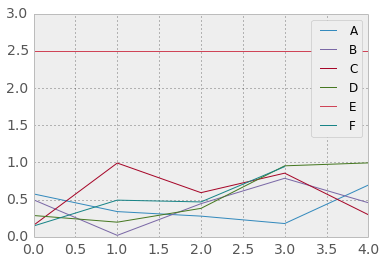

```python
df.plot(ylim=[0,3]);
```

```python
df[(df['A'] >= 0.5) & (df['B'] <= 0.5)]
```

|  | A | B | C | D | E | F |
| --- | --- | --- | --- | --- | --- | --- |
| 0 | 0.576212 | 0.497153 | 0.155229 | 0.286158 | 2.5 | 0.145339 |
| 4 | 0.695456 | 0.457891 | 0.296605 | 0.993321 | 2.5 | NaN |

2 rows × 6 columns

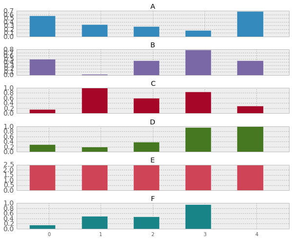

```python
df.plot(figsize=(10,8), subplots=True, sharex=True, kind='bar', rot=0);
```

## 2. Input and Output in pandas

Pandas has very powerful IO methods, allowing to load csv, excel, tab-delimited files very easily. Pandas DataFrames can also be saved also in csv, excel files.

```python
pd.read_
```

```python
SOI = pd.read_csv('./data/NIWA_SOI.csv')
```

```python
SOI.head()
```

|  | Unnamed: 0 | Jan | Feb | Mar | Apr | May | Jun | Jul | Aug | Sep | Oct | Nov | Dec |
| --- | --- | --- | --- | --- | --- | --- | --- | --- | --- | --- | --- | --- | --- |
| 0 | 1876 | NaN | NaN | NaN | NaN | NaN | NaN | NaN | NaN | NaN | NaN | NaN | NaN |
| 1 | 1877 | -1.044600 | -0.834198 | -0.759131 | -1.103454 | 0.349381 | -1.901213 | -1.002934 | -1.044881 | -1.839545 | -1.745311 | -1.453885 | -1.541774 |
| 2 | 1878 | -0.940401 | -2.339884 | -1.981073 | -1.009742 | 0.189664 | -0.448601 | 1.568691 | 1.216173 | 1.734780 | 1.002227 | 1.460825 | 1.744423 |
| 3 | 1879 | 1.404088 | 1.302904 | 1.257072 | 1.426758 | 0.189664 | 1.602146 | 2.147306 | 2.243925 | 1.858033 | 1.439335 | 0.905642 | -0.774995 |
| 4 | 1880 | 1.195689 | 0.622917 | 1.379266 | 0.583354 | 1.227823 | 0.833116 | 0.154297 | 1.353207 | 0.748760 | 0.377786 | 0.628051 | -0.391605 |

5 rows × 13 columns

```python
SOI.tail()
```

|  | Unnamed: 0 | Jan | Feb | Mar | Apr | May | Jun | Jul | Aug | Sep | Oct | Nov | Dec |
| --- | --- | --- | --- | --- | --- | --- | --- | --- | --- | --- | --- | --- | --- |
| 134 | 2010 | -1.096700 | -1.659897 | -1.431199 | 1.707893 | 0.988248 | 0.064086 | 2.018725 | 1.832825 | 2.474296 | 1.751556 | 1.599621 | 2.730281 |
| 135 | 2011 | 2.185585 | 2.128602 | 2.173528 | 2.832432 | 0.189664 | -0.106810 | 1.054366 | 0.051388 | 1.118517 | 0.627563 | 1.322029 | 2.292122 |
| 136 | 2012 | 1.039390 | 0.088641 | 0.096228 | -0.822319 | -0.289487 | -1.217631 | -0.167156 | -0.702297 | 0.194123 | 0.128010 | 0.281061 | -0.829765 |
| 137 | 2013 | -0.106804 | -0.542775 | 1.012684 | 0.021085 | 0.828531 | 1.345802 | 0.797204 | -0.222680 | 0.317375 | -0.309098 | 0.836244 | -0.117755 |
| 138 | 2014 | NaN | NaN | NaN | NaN | NaN | NaN | NaN | NaN | NaN | NaN | NaN | NaN |

5 rows × 13 columns

```python
SOI = pd.read_csv('./data/NIWA_SOI.csv', index_col=0)
```

```python
SOI.head()
```

|  | Jan | Feb | Mar | Apr | May | Jun | Jul | Aug | Sep | Oct | Nov | Dec |
| --- | --- | --- | --- | --- | --- | --- | --- | --- | --- | --- | --- | --- |
| 1876 | NaN | NaN | NaN | NaN | NaN | NaN | NaN | NaN | NaN | NaN | NaN | NaN |
| 1877 | -1.044600 | -0.834198 | -0.759131 | -1.103454 | 0.349381 | -1.901213 | -1.002934 | -1.044881 | -1.839545 | -1.745311 | -1.453885 | -1.541774 |
| 1878 | -0.940401 | -2.339884 | -1.981073 | -1.009742 | 0.189664 | -0.448601 | 1.568691 | 1.216173 | 1.734780 | 1.002227 | 1.460825 | 1.744423 |
| 1879 | 1.404088 | 1.302904 | 1.257072 | 1.426758 | 0.189664 | 1.602146 | 2.147306 | 2.243925 | 1.858033 | 1.439335 | 0.905642 | -0.774995 |
| 1880 | 1.195689 | 0.622917 | 1.379266 | 0.583354 | 1.227823 | 0.833116 | 0.154297 | 1.353207 | 0.748760 | 0.377786 | 0.628051 | -0.391605 |

5 rows × 12 columns

```python
SOI.index
```

```
Float64Index([1876.0, 1877.0, 1878.0, 1879.0, 1880.0, 1881.0, 1882.0, 1883.0, 1884.0, 1885.0, 1886.0, 1887.0, 1888.0, 1889.0, 1890.0, 1891.0, 1892.0, 1893.0, 1894.0, 1895.0, 1896.0, 1897.0, 1898.0, 1899.0, 1900.0, 1901.0, 1902.0, 1903.0, 1904.0, 1905.0, 1906.0, 1907.0, 1908.0, 1909.0, 1910.0, 1911.0…
```

```python
SOI = SOI.dropna()
```

```python
SOI.head()
```

|  | Jan | Feb | Mar | Apr | May | Jun | Jul | Aug | Sep | Oct | Nov | Dec |
| --- | --- | --- | --- | --- | --- | --- | --- | --- | --- | --- | --- | --- |
| 1877 | -1.044600 | -0.834198 | -0.759131 | -1.103454 | 0.349381 | -1.901213 | -1.002934 | -1.044881 | -1.839545 | -1.745311 | -1.453885 | -1.541774 |
| 1878 | -0.940401 | -2.339884 | -1.981073 | -1.009742 | 0.189664 | -0.448601 | 1.568691 | 1.216173 | 1.734780 | 1.002227 | 1.460825 | 1.744423 |
| 1879 | 1.404088 | 1.302904 | 1.257072 | 1.426758 | 0.189664 | 1.602146 | 2.147306 | 2.243925 | 1.858033 | 1.439335 | 0.905642 | -0.774995 |
| 1880 | 1.195689 | 0.622917 | 1.379266 | 0.583354 | 1.227823 | 0.833116 | 0.154297 | 1.353207 | 0.748760 | 0.377786 | 0.628051 | -0.391605 |
| 1881 | -0.784101 | -0.737057 | -0.025966 | 0.021085 | -0.449204 | -0.619496 | -0.552899 | -1.387465 | -1.469787 | -2.557084 | 0.628051 | 0.868104 |

5 rows × 12 columns

```python
SOI.index
```

```
Float64Index([1877.0, 1878.0, 1879.0, 1880.0, 1881.0, 1882.0, 1883.0, 1884.0, 1885.0, 1886.0, 1887.0, 1888.0, 1889.0, 1890.0, 1891.0, 1892.0, 1893.0, 1894.0, 1895.0, 1896.0, 1897.0, 1898.0, 1899.0, 1900.0, 1901.0, 1902.0, 1903.0, 1904.0, 1905.0, 1906.0, 1907.0, 1908.0, 1909.0, 1910.0, 1911.0, 1912.0…
```

```python
SOI.index = np.array(SOI.index.to_native_types(), dtype=np.int)
```

```python
SOI.index
```

```
Int64Index([1877, 1878, 1879, 1880, 1881, 1882, 1883, 1884, 1885, 1886, 1887, 1888, 1889, 1890, 1891, 1892, 1893, 1894, 1895, 1896, 1897, 1898, 1899, 1900, 1901, 1902, 1903, 1904, 1905, 1906, 1907, 1908, 1909, 1910, 1911, 1912, 1913, 1914, 1915, 1916, 1917, 1918, 1919, 1920, 1921, 1922, 1923, 1924, …
```

#### Stacking

```python
SOIs = SOI.stack()
```

```python
SOIs.head()
```

```
1877  Jan   -1.044600
      Feb   -0.834198
      Mar   -0.759131
      Apr   -1.103454
      May    0.349381
dtype: float64
```

```python
SOIs.index
```

```
MultiIndex(levels=[[1877, 1878, 1879, 1880, 1881, 1882, 1883, 1884, 1885, 1886, 1887, 1888, 1889, 1890, 1891, 1892, 1893, 1894, 1895, 1896, 1897, 1898, 1899, 1900, 1901, 1902, 1903, 1904, 1905, 1906, 1907, 1908, 1909, 1910, 1911, 1912, 1913, 1914, 1915, 1916, 1917, 1918, 1919, 1920, 1921, 1922, 1923…
           labels=[[0, 0, 0, 0, 0, 0, 0, 0, 0, 0, 0, 0, 1, 1, 1, 1, 1, 1, 1, 1, 1, 1, 1, 1, 2, 2, 2, 2, 2, 2, 2, 2, 2, 2, 2, 2, 3, 3, 3, 3, 3, 3, 3, 3, 3, 3, 3, 3, 4, 4, 4, 4, 4, 4, 4, 4, 4, 4, 4, 4, 5, 5, 5, 5, 5, 5, 5, 5, 5, 5, 5, 5, 6, 6, 6, 6, 6, 6, 6, 6, 6, 6, 6, 6, 7, 7, 7, 7, 7, 7, 7, 7, 7, 7…
```

```python
from dateutil import parser
```

```python
dateindex = [parser.parse("-".join(map(str,[x[0],x[1], 1]))) for x in SOIs.index]
```

```python
dateindex
```

```
[datetime.datetime(1877, 1, 1, 0, 0),
 datetime.datetime(1877, 2, 1, 0, 0),
 datetime.datetime(1877, 3, 1, 0, 0),
 datetime.datetime(1877, 4, 1, 0, 0),
 datetime.datetime(1877, 5, 1, 0, 0),
 datetime.datetime(1877, 6, 1, 0, 0),
 datetime.datetime(1877, 7, 1, 0, 0),
 datetime.datetime(1877, 8, 1, 0, 0),
 datetime.datetime(1877, 9, 1, 0, 0),
 datetime.datetime(1877, 10, 1, 0, 0),
 datetime.datetime(1877, 11, 1, 0, 0),
 datetime.datetime(1877, 12, 1, 0, 0),
 datetime.datetime(1878, 1, 1, 0, 0),
 datetime.datetime(1878, 2, 1, 0, 0),
 datetime.datetime(1878, 3, 1, 0, 0),
 datetime.datetime(1878, 4, 1, 0, 0),
 datetime.datetime(1878, 5, 1, 0, 0),
 datetime.datetime(1878, 6, 1, 0, 0),
 datetime.datetime(1878, 7, 1, 0, 0),
 datetime.datetime(1878, 8, 1, 0, 0),
 datetime.datetime(1878, 9, 1, 0, 0),
 datetime.datetime(1878, 10, 1, 0, 0),
 datetime.datetime(1878, 11, 1, 0, 0),
 datetime.datetime(1878, 12, 1, 0, 0),
 datetime.datetime(1879, 1, 1, 0, 0),
 datetime.datetime(1879, 2, 1, 0, 0),
 datetime.datetime(1879, 3, 1, 0, 0),
 datetime.datetime(1879, 4, 1, 0, 0),
 datetime.datetime(1879, 5, 1, 0, 0),
 datetime.datetime(1879, 6, 1, 0, 0),
 datetime.datetime(1879, 7, 1, 0, 0),
 datetime.datetime(1879, 8, 1, 0, 0),
 datetime.datetime(1879, 9, 1, 0, 0),
 datetime.datetime(1879, 10, 1, 0, 0),
 datetime.datetime(1879, 11, 1, 0, 0),
 datetime.datetime(1879, 12, 1, 0, 0),
 datetime.datetime(1880, 1, 1, 0, 0),
 datetime.datetime(1880, 2, 1, 0, 0),
 datetime.datetime(1880, 3, 1, 0, 0),
 datetime.datetime(1880, 4, 1, 0, 0),
```

[output cut: 946 more lines]

```
 datetime.datetime(1959, 3, 1, 0, 0),
 datetime.datetime(1959, 4, 1, 0, 0),
 datetime.datetime(1959, 5, 1, 0, 0),
 datetime.datetime(1959, 6, 1, 0, 0),
 datetime.datetime(1959, 7, 1, 0, 0),
 datetime.datetime(1959, 8, 1, 0, 0),
 datetime.datetime(1959, 9, 1, 0, 0),
 datetime.datetime(1959, 10, 1, 0, 0),
 datetime.datetime(1959, 11, 1, 0, 0),
 datetime.datetime(1959, 12, 1, 0, 0),
 datetime.datetime(1960, 1, 1, 0, 0),
 datetime.datetime(1960, 2, 1, 0, 0),
 datetime.datetime(1960, 3, 1, 0, 0),
 datetime.datetime(1960, 4, 1, 0, 0),
 ...]
```

```python
SOIs.index=dateindex
```

```python
SOIs.head()
```

```
1877-01-01   -1.044600
1877-02-01   -0.834198
1877-03-01   -0.759131
1877-04-01   -1.103454
1877-05-01    0.349381
dtype: float64
```

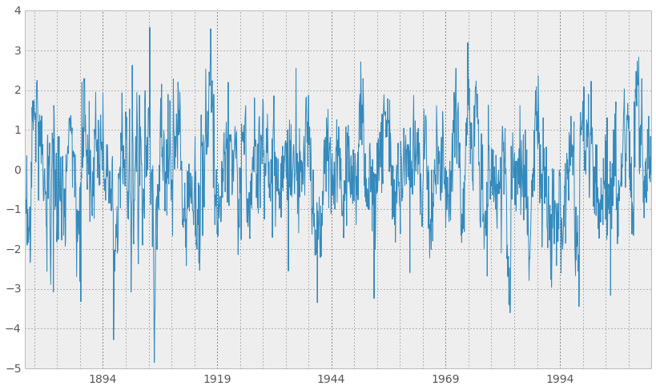

```python
SOIs.plot(figsize=(14,8))
```

## 3. The GroupBy method

The **groupby** method is a very powerful method of pandas DataFrames, in a nutschell it allows you to

1. **split** your data according to unique values of a variable (or unique *combinations* of *N* variables)
2. **apply** some operation to the groups thus defined, either an *aggregation* or *transformation* method
3. **combine** the results into a DataFrame

A very nice explanation of the **groupby** method, with examples, is available from Pandas's documentation at:

http://pandas.pydata.org/pandas-docs/stable/groupby.html

and a short tutorial on Wes McKinney's blog [here](http://wesmckinney.com/blog/?p=125)

```python
Image(filename='images/split-apply-combine.png', width=800)
```

[output not shown]

```python
url = "ftp://ftp.cpc.ncep.noaa.gov/wd52dg/data/indices/ersst3b.nino.mth.81-10.ascii"
```

```python
#!wget -P ./data ftp://ftp.cpc.ncep.noaa.gov/wd52dg/data/indices/ersst3b.nino.mth.81-10.ascii
```

```python
data = pd.read_table(url, sep='\s+')
```

```python
data.tail()
```

|  | YR | MON | NINO1+2 | ANOM | NINO3 | ANOM.1 | NINO4 | ANOM.2 | NINO3.4 | ANOM.3 |
| --- | --- | --- | --- | --- | --- | --- | --- | --- | --- | --- |
| 767 | 2013 | 12 | 22.61 | -0.40 | 25.01 | -0.30 | 28.28 | -0.26 | 26.20 | -0.49 |
| 768 | 2014 | 1 | 24.47 | -0.22 | 25.30 | -0.47 | 27.91 | -0.42 | 26.03 | -0.64 |
| 769 | 2014 | 2 | 25.29 | -0.82 | 25.85 | -0.65 | 28.04 | -0.13 | 26.05 | -0.77 |
| 770 | 2014 | 3 | 25.97 | -0.54 | 27.04 | -0.20 | 28.26 | -0.03 | 26.84 | -0.49 |
| 771 | 2014 | 4 | 25.17 | -0.44 | 27.53 | -0.02 | 28.76 | 0.21 | 27.62 | -0.17 |

5 rows × 10 columns

I only keep the raw - monthly - values of NINO 3.4

```python
nino = data[['YR','MON','NINO3.4']]
```

```python
nino.head()
```

|  | YR | MON | NINO3.4 |
| --- | --- | --- | --- |
| 0 | 1950 | 1 | 24.83 |
| 1 | 1950 | 2 | 25.20 |
| 2 | 1950 | 3 | 26.03 |
| 3 | 1950 | 4 | 26.36 |
| 4 | 1950 | 5 | 26.19 |

5 rows × 3 columns

Now I want to calculate a climatology (over the whole period available)

I first group by UNIQUE values of the variable months, I should get 12 groups

```python
groups = nino.groupby('MON')
```

```python
for month, group in groups:
    print month
    print group.head()
```

```
1
      YR  MON  NINO3.4
0   1950    1    24.83
12  1951    1    25.46
24  1952    1    26.85
36  1953    1    26.85
48  1954    1    27.03

[5 rows x 3 columns]
2
      YR  MON  NINO3.4
1   1950    2    25.20
13  1951    2    25.78
25  1952    2    26.79
37  1953    2    27.19
49  1954    2    27.22

[5 rows x 3 columns]
3
      YR  MON  NINO3.4
2   1950    3    26.03
14  1951    3    26.72
26  1952    3    27.32
38  1953    3    27.68
50  1954    3    27.21

[5 rows x 3 columns]
4
      YR  MON  NINO3.4
3   1950    4    26.36
15  1951    4    27.24
27  1952    4    27.88
39  1953    4    28.19
51  1954    4    26.87

[5 rows x 3 columns]
5
      YR  MON  NINO3.4
4   1950    5    26.19
16  1951    5    27.68
```

[output cut: 53 more lines]

```
22  1951   11    27.48
34  1952   11    26.36
46  1953   11    26.96
58  1954   11    25.67

[5 rows x 3 columns]
12
      YR  MON  NINO3.4
11  1950   12    25.50
23  1951   12    27.12
35  1952   12    26.53
47  1953   12    26.99
59  1954   12    25.37

[5 rows x 3 columns]
```

```python
climatology = groups.mean()
```

Same as

```
climatology = groups.aggregate(np.mean)
```

```python
climatology['NINO3.4'].head(12)
```

```
MON
1      26.484615
2      26.676923
3      27.184154
4      27.622923
5      27.733281
6      27.540469
7      27.149844
8      26.764531
9      26.667344
10     26.632656
11     26.593750
12     26.529062
Name: NINO3.4, dtype: float64
```

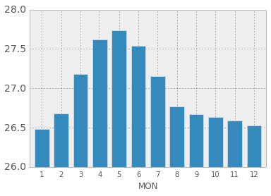

```python
climatology['NINO3.4'].plot(kind='bar',ylim=[26,28], rot=0)
```

Now suppose we want to apply a function that doesnt **aggregate** the values in the groups (such as sum, or mean) but rather want to apply a function to those values ...

An example would be calculating the standardized anomalies per month (to each value subtract the mean of the corresponding month, then divide by the standard-deviation)

```python
def zscore(x):
    z = (x - x.mean()) / x.std()
    return z
```

```python
transformed = groups.transform(zscore)
```

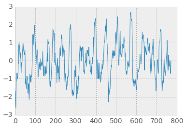

```python
transformed['NINO3.4'].plot()
```

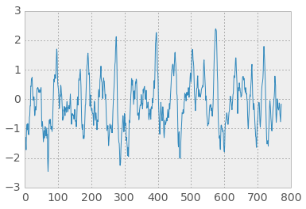

```python
data['ANOM.3'].plot()
```

## 4. Some more data manipulation with Pandas

This is some real data provided by Dan Smale (Lauder). It is a summary file of daily QA/QC (data quality) diagnostics of raw GPS data collected at NIWA Lauder. The GPS data can be used to infer the amount of total column water vapour in the atmosphere (above lauder).

Summary of data /data/gruan/gnss_processing/data/netr9_laud/rinex_211/LAUD0010.13S:SUM 13 1 1 00:00 13 1 1 23:59 24.00 30 25298 23597 93 0.57 0.43 11799

- 13 1 1 00:00 13 1 1 23:59: time period the QC/QA variables are calculated for.
- 24 = number of hourly entries
- 30 = dt
- 25298 = #expt = number of data points expected
- 23597 = #have = number of data points collected
- 93 =% #have/#expt*100
- 0.57 = mp1 = mean path 1
- 0.43 = mp2 = mean path 2
- 11799 =o/slps = number of time slips

```python
data = pd.read_table('./data/teqc_SUM.dat', sep='\s+', header=None) ## the '\s+' is a regular expression
```

```python
data.head()
```

|  | 0 | 1 | 2 | 3 | 4 | 5 | 6 | 7 | 8 | 9 | 10 | 11 | 12 | 13 | 14 | 15 | 16 |
| --- | --- | --- | --- | --- | --- | --- | --- | --- | --- | --- | --- | --- | --- | --- | --- | --- | --- |
| 0 | /data/gruan/gnss_processing/data/netr9_laud/ri... | 13 | 1 | 1 | 00:00 | 13 | 1 | 1 | 23:59 | 24 | 30 | 25298 | 23597 | 93 | 0.57 | 0.43 | 11799 |
| 1 | /data/gruan/gnss_processing/data/netr9_laud/ri... | 13 | 1 | 2 | 00:00 | 13 | 1 | 2 | 23:59 | 24 | 30 | 24530 | 22652 | 92 | 0.58 | 0.42 | 22652 |
| 2 | /data/gruan/gnss_processing/data/netr9_laud/ri... | 13 | 1 | 3 | 00:00 | 13 | 1 | 3 | 23:59 | 24 | 30 | 25296 | 23235 | 92 | 0.61 | 0.43 | 5809 |
| 3 | /data/gruan/gnss_processing/data/netr9_laud/ri... | 13 | 1 | 4 | 00:00 | 13 | 1 | 4 | 23:59 | 24 | 30 | 25300 | 23939 | 95 | 0.59 | 0.45 | 7980 |
| 4 | /data/gruan/gnss_processing/data/netr9_laud/ri... | 13 | 1 | 5 | 00:00 | 13 | 1 | 5 | 23:59 | 24 | 30 | 25301 | 24581 | 97 | 0.64 | 0.43 | 12291 |

5 rows × 17 columns

```python
data = pd.read_table('./data/teqc_SUM.dat', header=None, sep='\s+', \
                     names=['path','year1','m1','d1','t1','year2','m2','d2','t2','nh','nd','c1','c2','c3','c4','c5','c6'])
```

```python
data.head()
```

|  | path | year1 | m1 | d1 | t1 | year2 | m2 | d2 | t2 | nh | nd | c1 | c2 | c3 | c4 | c5 | c6 |
| --- | --- | --- | --- | --- | --- | --- | --- | --- | --- | --- | --- | --- | --- | --- | --- | --- | --- |
| 0 | /data/gruan/gnss_processing/data/netr9_laud/ri... | 13 | 1 | 1 | 00:00 | 13 | 1 | 1 | 23:59 | 24 | 30 | 25298 | 23597 | 93 | 0.57 | 0.43 | 11799 |
| 1 | /data/gruan/gnss_processing/data/netr9_laud/ri... | 13 | 1 | 2 | 00:00 | 13 | 1 | 2 | 23:59 | 24 | 30 | 24530 | 22652 | 92 | 0.58 | 0.42 | 22652 |
| 2 | /data/gruan/gnss_processing/data/netr9_laud/ri... | 13 | 1 | 3 | 00:00 | 13 | 1 | 3 | 23:59 | 24 | 30 | 25296 | 23235 | 92 | 0.61 | 0.43 | 5809 |
| 3 | /data/gruan/gnss_processing/data/netr9_laud/ri... | 13 | 1 | 4 | 00:00 | 13 | 1 | 4 | 23:59 | 24 | 30 | 25300 | 23939 | 95 | 0.59 | 0.45 | 7980 |
| 4 | /data/gruan/gnss_processing/data/netr9_laud/ri... | 13 | 1 | 5 | 00:00 | 13 | 1 | 5 | 23:59 | 24 | 30 | 25301 | 24581 | 97 | 0.64 | 0.43 | 12291 |

5 rows × 17 columns

We want the index (row wise) to properly represent datetime info

```python
from datetime import datetime
```

```python
data.index = [datetime(y,m,d) for y,m,d in zip(data.year1+2000,data.m1,data.d1)]  # note that we are using list comprehension
```

```python
data.head()
```

|  | path | year1 | m1 | d1 | t1 | year2 | m2 | d2 | t2 | nh | nd | c1 | c2 | c3 | c4 | c5 | c6 |
| --- | --- | --- | --- | --- | --- | --- | --- | --- | --- | --- | --- | --- | --- | --- | --- | --- | --- |
| 2013-01-01 | /data/gruan/gnss_processing/data/netr9_laud/ri... | 13 | 1 | 1 | 00:00 | 13 | 1 | 1 | 23:59 | 24 | 30 | 25298 | 23597 | 93 | 0.57 | 0.43 | 11799 |
| 2013-01-02 | /data/gruan/gnss_processing/data/netr9_laud/ri... | 13 | 1 | 2 | 00:00 | 13 | 1 | 2 | 23:59 | 24 | 30 | 24530 | 22652 | 92 | 0.58 | 0.42 | 22652 |
| 2013-01-03 | /data/gruan/gnss_processing/data/netr9_laud/ri... | 13 | 1 | 3 | 00:00 | 13 | 1 | 3 | 23:59 | 24 | 30 | 25296 | 23235 | 92 | 0.61 | 0.43 | 5809 |
| 2013-01-04 | /data/gruan/gnss_processing/data/netr9_laud/ri... | 13 | 1 | 4 | 00:00 | 13 | 1 | 4 | 23:59 | 24 | 30 | 25300 | 23939 | 95 | 0.59 | 0.45 | 7980 |
| 2013-01-05 | /data/gruan/gnss_processing/data/netr9_laud/ri... | 13 | 1 | 5 | 00:00 | 13 | 1 | 5 | 23:59 | 24 | 30 | 25301 | 24581 | 97 | 0.64 | 0.43 | 12291 |

5 rows × 17 columns

```python
data.pop('path') # we pop the 'path' variable, ve careful it operates in place
```

```
2013-01-01    /data/gruan/gnss_processing/data/netr9_laud/ri...
2013-01-02    /data/gruan/gnss_processing/data/netr9_laud/ri...
2013-01-03    /data/gruan/gnss_processing/data/netr9_laud/ri...
2013-01-04    /data/gruan/gnss_processing/data/netr9_laud/ri...
2013-01-05    /data/gruan/gnss_processing/data/netr9_laud/ri...
2013-01-06    /data/gruan/gnss_processing/data/netr9_laud/ri...
2013-01-07    /data/gruan/gnss_processing/data/netr9_laud/ri...
2013-01-08    /data/gruan/gnss_processing/data/netr9_laud/ri...
2013-01-09    /data/gruan/gnss_processing/data/netr9_laud/ri...
2013-01-10    /data/gruan/gnss_processing/data/netr9_laud/ri...
2013-01-11    /data/gruan/gnss_processing/data/netr9_laud/ri...
2013-01-12    /data/gruan/gnss_processing/data/netr9_laud/ri...
2013-01-13    /data/gruan/gnss_processing/data/netr9_laud/ri...
2013-01-14    /data/gruan/gnss_processing/data/netr9_laud/ri...
2013-01-15    /data/gruan/gnss_processing/data/netr9_laud/ri...
...
2012-12-17    /data/gruan/gnss_processing/data/netr9_laud/ri...
2012-12-18    /data/gruan/gnss_processing/data/netr9_laud/ri...
2012-12-19    /data/gruan/gnss_processing/data/netr9_laud/ri...
2012-12-20    /data/gruan/gnss_processing/data/netr9_laud/ri...
2012-12-21    /data/gruan/gnss_processing/data/netr9_laud/ri...
2012-12-22    /data/gruan/gnss_processing/data/netr9_laud/ri...
2012-12-23    /data/gruan/gnss_processing/data/netr9_laud/ri...
2012-12-24    /data/gruan/gnss_processing/data/netr9_laud/ri...
2012-12-25    /data/gruan/gnss_processing/data/netr9_laud/ri...
2012-12-26    /data/gruan/gnss_processing/data/netr9_laud/ri...
2012-12-27    /data/gruan/gnss_processing/data/netr9_laud/ri...
2012-12-28    /data/gruan/gnss_processing/data/netr9_laud/ri...
2012-12-29    /data/gruan/gnss_processing/data/netr9_laud/ri...
2012-12-30    /data/gruan/gnss_processing/data/netr9_laud/ri...
2012-12-31    /data/gruan/gnss_processing/data/netr9_laud/ri...
Name: path, Length: 551
```

```python
data.head()
```

|  | year1 | m1 | d1 | t1 | year2 | m2 | d2 | t2 | nh | nd | c1 | c2 | c3 | c4 | c5 | c6 |
| --- | --- | --- | --- | --- | --- | --- | --- | --- | --- | --- | --- | --- | --- | --- | --- | --- |
| 2013-01-01 | 13 | 1 | 1 | 00:00 | 13 | 1 | 1 | 23:59 | 24 | 30 | 25298 | 23597 | 93 | 0.57 | 0.43 | 11799 |
| 2013-01-02 | 13 | 1 | 2 | 00:00 | 13 | 1 | 2 | 23:59 | 24 | 30 | 24530 | 22652 | 92 | 0.58 | 0.42 | 22652 |
| 2013-01-03 | 13 | 1 | 3 | 00:00 | 13 | 1 | 3 | 23:59 | 24 | 30 | 25296 | 23235 | 92 | 0.61 | 0.43 | 5809 |
| 2013-01-04 | 13 | 1 | 4 | 00:00 | 13 | 1 | 4 | 23:59 | 24 | 30 | 25300 | 23939 | 95 | 0.59 | 0.45 | 7980 |
| 2013-01-05 | 13 | 1 | 5 | 00:00 | 13 | 1 | 5 | 23:59 | 24 | 30 | 25301 | 24581 | 97 | 0.64 | 0.43 | 12291 |

5 rows × 16 columns

Sort the dataframe according to the index values (rowwise)

Note that for plotting purposes, you don't even have to do that, pandas + matplotlib understand that the dates need to be in chronological order

```python
data2 = data.sort()
```

```python
data2.head()
```

|  | year1 | m1 | d1 | t1 | year2 | m2 | d2 | t2 | nh | nd | c1 | c2 | c3 | c4 | c5 | c6 |
| --- | --- | --- | --- | --- | --- | --- | --- | --- | --- | --- | --- | --- | --- | --- | --- | --- |
| 2012-04-28 | 12 | 4 | 28 | 00:00 | 12 | 4 | 28 | 23:59 | 24 | 30 | 25462 | 25461 | 100 | 0.55 | 0.42 | 25461 |
| 2012-05-02 | 12 | 5 | 2 | 01:00 | 12 | 5 | 2 | 23:59 | 23 | 30 | 24480 | 24480 | 100 | 0.56 | 0.42 | 24480 |
| 2012-05-03 | 12 | 5 | 3 | 00:00 | 12 | 5 | 3 | 23:59 | 24 | 30 | 25455 | 25455 | 100 | 0.55 | 0.43 | 12728 |
| 2012-05-04 | 12 | 5 | 4 | 00:00 | 12 | 5 | 4 | 23:59 | 24 | 30 | 25459 | 25458 | 100 | 0.55 | 0.42 | 25458 |
| 2012-05-05 | 12 | 5 | 5 | 00:00 | 12 | 5 | 5 | 23:59 | 24 | 30 | 25451 | 25450 | 100 | 0.54 | 0.42 | 12725 |

5 rows × 16 columns

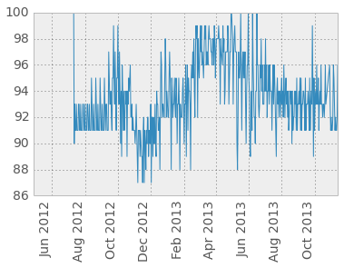

```python
data['c3'].plot(rot=90)
```

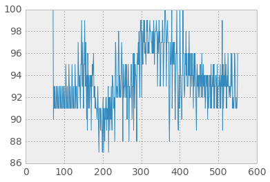

```python
plt.plot(data2.c3.values)
```

```python
data.columns
```

```
Index([u'year1', u'm1', u'd1', u't1', u'year2', u'm2', u'd2', u't2', u'nh', u'nd', u'c1', u'c2', u'c3', u'c4', u'c5', u'c6'], dtype='object')
```

```python
data2 = data[data.columns[-6:]]
# same as data2 = data[['c1','c2','c3','c4','c5','c6']] or data2 = data.ix[:,10::]
```

```python
data2.head()
```

|  | c1 | c2 | c3 | c4 | c5 | c6 |
| --- | --- | --- | --- | --- | --- | --- |
| 2013-01-01 | 25298 | 23597 | 93 | 0.57 | 0.43 | 11799 |
| 2013-01-02 | 24530 | 22652 | 92 | 0.58 | 0.42 | 22652 |
| 2013-01-03 | 25296 | 23235 | 92 | 0.61 | 0.43 | 5809 |
| 2013-01-04 | 25300 | 23939 | 95 | 0.59 | 0.45 | 7980 |
| 2013-01-05 | 25301 | 24581 | 97 | 0.64 | 0.43 | 12291 |

5 rows × 6 columns

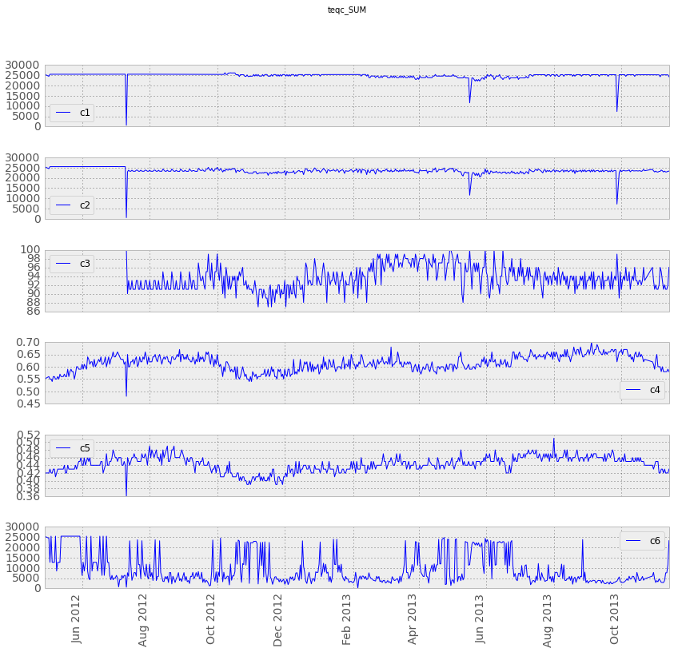

```python
data2.plot(subplots=True, sharex=True, color='b', title='teqc_SUM', figsize=(14,13), rot=90)
plt.savefig('teqc_SUM.pdf')
```

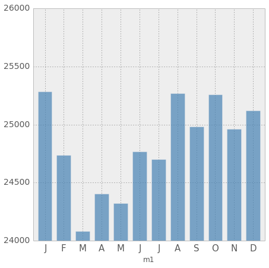

```python
f, ax = plt.subplots(1,1, figsize=(7,7))
data.groupby(data['m1']).mean()['c1'].plot(kind='bar', ylim=[24000,26000], color='steelblue',alpha=.7, ax=ax)
ax.set_xticklabels(list('JFMAMJJASOND'), rotation=None, fontsize=15);
```

[output not shown]

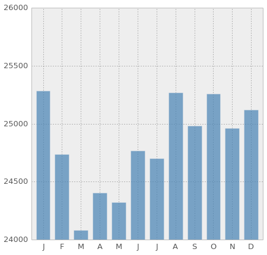

```python
f, ax = plt.subplots(1,1, figsize=(7,7))
data.groupby(data.index.month).mean()['c1'].plot(kind='bar',\
                                                 ylim=[24000,26000], color='steelblue',alpha=.7, ax=ax)
ax.set_xticklabels(list('JFMAMJJASOND'), rotation=None, fontsize=13);
[f.set_fontsize(13) for f in ax.yaxis.get_ticklabels()] # list comprehension again
```